# More Intuitive Regression Output

Nick Strayer

April 19, 2017

## Motivation

Recently I was pointed in the direction of a post titled [Visualizing Regression](http://stephanieevergreen.com/visualizing-regression/) on the blog of the popular data-visualization practisioner Stephanie Evergreen (although it is a guest post and not written by Stephanie). In it the authors point out the fact that common regression tables are an all around bad way of reporting the results of a regression. While I whole heartedly agree with the premise there were a few rather large mistakes in the interpretations behind the regression output.

Having lived in both the data visualization world (I worked as a “data-artist in residence” at a tech startup in California and also having been a reporter in the graphics department at the New York Times) and also the statistics world (I have an Bachlors in statistics and am currently working towards my PhD) I have many thoughts on issues like this.

I firmly believe that in order to make a truly great visualization you must be utterly familiar with the underlying mechanisms behind what you are visualizing. Pretty regression results are absolutely what we should shoot for, as long as they are utterly truthful to the true meaning of the data/statistics they are visually encoding.

This is not an easy task at all. The reason regression tables are still used so much is two fold. **One:** the person reading the table is a statistian and have gone through a terrible amount of school to be able to look at the rows and columns and understand what they mean. **Two:** making a better representation is hard and not the primary focus of most statisticians.

I have visualized a lot of regression outputs in my course work and jobs and while I have never had the pleasure of doing a full proper study into effectiveness of different representations I have developed a style that I believe helps immediately impart the important results from a regression model, including effect size and confidence intervals, while also appeasing those who desire the non-nonesense precision of a table. I am not saying this is the perfect way (or even a particularly good way) but I do believe it’s better than what I see in 95% of papers/ reports I read.

## My Solution

In order to demonstrate the utility of my result form I will generate some fake data that we will fit a few models to.

**Data**:

Next we generate some fake data.

```r
num_obs <- 200

my_cool_data <- data_frame(
  x1 = rnorm(num_obs, mean = 1, sd = 10),
  x2 = rnorm(num_obs, mean = 1, sd = 20),
  x3 = runif(num_obs),
  y  = 10 + 1.2*x1 + -.312*x2 + 0*x3 + 5*x1*x3 + rnorm(num_obs, mean = 5)
)
```

This is a contrived example but note that the true outcome generation procedure has an interaction between `x1` and `x3` and no true relationship between `x3` alone and the outcome.

**Fit Models:**

Now that we have some fake data we can fit three different plain linear models to it.

```r
no_interaction    <- lm(y ~ x1 + x2 + x3, data = my_cool_data)
wrong_interaction <- lm(y ~ x1 + x2 + x3 + x2:x3, data = my_cool_data)
right_interaction <- lm(y ~ x1 + x2 + x3 + x1:x3, data = my_cool_data)
```

Another note, this is not really a fair comparison but I’m doing it to keep the data-generation simple. When we compare model coefficients in almost every scenario we would want all of the models to contain exactly the same terms as then the inference on them will be comparable. For instance you would compare a model done with Lasso penalization to a non-penalized model with the same values to see the extent of shrinkage on your coefficients. I recognize the irony in attempting to demonstrate a statistially sound practice by using statistically unsound practices.

**Show It:**

Lastly we can plot the results for the coefficient estimates for these models.

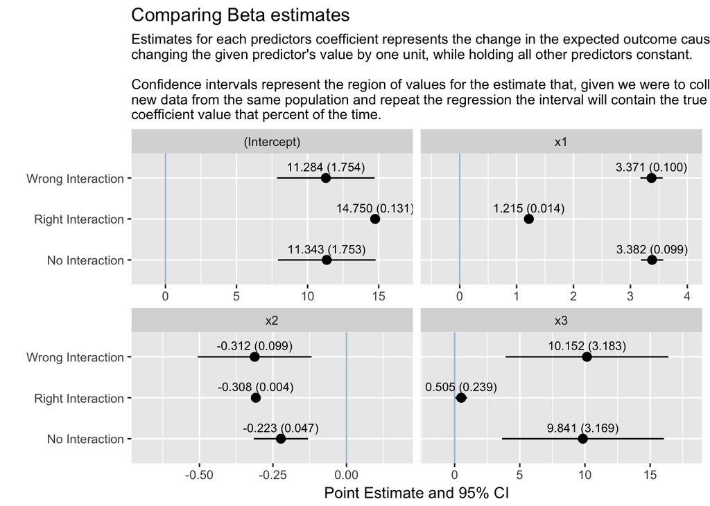

```r
my_models <- list(no_interaction, wrong_interaction, right_interaction )
names(my_models) <- c("No Interaction", "Wrong Interaction", "Right Interaction")

regression_viz(my_models, plot_title = "Comparing Beta estimates")
```

The most important aspect of this chart are the descriptions above. Reminding the viewer what the true intepretation of a coefficient is (something statisticians have to do themselves regularly), in addition making the confidence interval meaning clear as well.

## How to make it better

Like I said before I realize this plot could be way better. The immediate things that jump out to me about it are:

- *It’s the same dot and line style that everyone uses.* I do wish I knew how to visualize frequentist uncertianty better. It’s a tough issue and attempts to simplify it often get it wrong (see the blog post from the start of this.) The truth is frequentist confidence intervals make absolutely no statment about probabilities in them, it’s just an interval that should somewhere within it contain the true value if the experiement was repeated a ton of times. This carries into the next point…
- *There are so many words!* Again, yes, I know and I don’t like it. Ideally a visualization would just impart these characteristics to the viewer, but I am not clever enough to have figured out how to do that with regression models. Ultimately the math behind a point estimate or a confidence interval is non-trivial and sometimes you have to read to put yourself into the correct mindframe to interpret the following picture.

## Further

As was obvious, this is simply a function I called. It is a function in my personal R package nviz. Currently it is only on github but it can be installed using devtools with `devtools::install_github('nstrayer/nviz')`.